# QGAM modelling of extreme rainfall in Switzerland: solution

Matteo Fasiolo

2025-05-27

```r
library(mgcViz);
library(gamair);
data(swer)

form <- exra ~ s(nao) + s(elevation) + climate.region + s(E, N) + s(year, k = 5)
fit <- qgamV(form, data = swer, qu = 0.5)
```

```
## Estimating learning rate. Each dot corresponds to a loss evaluation.
## qu = 0.5..............done
```

```r
summary(fit)
```

```
##
## Family: elf
## Link function: identity
##
## Formula:
## exra ~ s(nao) + s(elevation) + climate.region + s(E, N) + s(year,
##     k = 5)
##
## Parametric coefficients:
##                                            Estimate Std. Error z value Pr(>|z|)
## (Intercept)                                  69.178      3.830  18.060  < 2e-16
## climate.regionCentral Alpine north slope    -24.715      4.888  -5.056 4.28e-07
## climate.regionCentral plateau               -23.586      5.579  -4.228 2.36e-05
## climate.regionEastern Alpine north slope    -15.027      5.839  -2.573 0.010069
## climate.regionEastern Jura                  -21.110      6.155  -3.430 0.000604
## climate.regionEngadine                      -18.305      3.693  -4.957 7.15e-07
## climate.regionNorth-eastern plateau         -14.058      6.157  -2.283 0.022424
## climate.regionNorthern and central Grisons  -15.244      4.235  -3.599 0.000319
## climate.regionValais                        -29.679      5.198  -5.710 1.13e-08
## climate.regionWestern Alpine north slope    -29.232      4.963  -5.890 3.86e-09
## climate.regionWestern Jura                  -19.742      6.712  -2.941 0.003267
## climate.regionWestern plateau               -20.233      6.306  -3.208 0.001335
##
## (Intercept)                                ***
## climate.regionCentral Alpine north slope   ***
## climate.regionCentral plateau              ***
## climate.regionEastern Alpine north slope   *
## climate.regionEastern Jura                 ***
## climate.regionEngadine                     ***
## climate.regionNorth-eastern plateau        *
## climate.regionNorthern and central Grisons ***
## climate.regionValais                       ***
## climate.regionWestern Alpine north slope   ***
## climate.regionWestern Jura                 **
## climate.regionWestern plateau              **
## ---
## Signif. codes:  0 '***' 0.001 '**' 0.01 '*' 0.05 '.' 0.1 ' ' 1
##
## Approximate significance of smooth terms:
##                 edf Ref.df  Chi.sq  p-value
## s(nao)        6.490  7.556  29.619 0.000187 ***
## s(elevation)  6.089  7.035  94.818  < 2e-16 ***
## s(E,N)       23.875 27.014 301.554  < 2e-16 ***
## s(year)       1.000  1.000   0.011 0.916395
## ---
## Signif. codes:  0 '***' 0.001 '**' 0.01 '*' 0.05 '.' 0.1 ' ' 1
##
## R-sq.(adj) =  0.486   Deviance explained = 38.2%
## -REML = 9182.1  Scale est. = 1         n = 2196
```

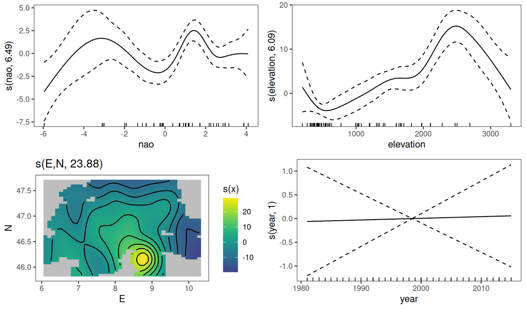

```r
print(plot(fit), pages = 1)
```

2. Fit a smooth trend for each climate region:

```r
fit2 <- qgamV(exra ~ s(nao) + s(elevation) +
                     s(year, climate.region, bs = "fs", k = 5) + s(E, N),
                     data = swer, qu = 0.5)
```

```
## Estimating learning rate. Each dot corresponds to a loss evaluation.
## qu = 0.5..........done
```

```r
summary(fit2)
```

```
##
## Family: elf
## Link function: identity
##
## Formula:
## exra ~ s(nao) + s(elevation) + s(year, climate.region, bs = "fs",
##     k = 5) + s(E, N)
##
## Parametric coefficients:
##             Estimate Std. Error z value Pr(>|z|)
## (Intercept)   50.258      1.805   27.85   <2e-16 ***
## ---
## Signif. codes:  0 '***' 0.001 '**' 0.01 '*' 0.05 '.' 0.1 ' ' 1
##
## Approximate significance of smooth terms:
##                           edf Ref.df Chi.sq  p-value
## s(nao)                  6.613  7.656  31.33 9.79e-05 ***
## s(elevation)            6.001  6.932 106.51  < 2e-16 ***
## s(year,climate.region) 13.109 59.000  52.80  < 2e-16 ***
## s(E,N)                 25.285 27.605 344.37  < 2e-16 ***
## ---
## Signif. codes:  0 '***' 0.001 '**' 0.01 '*' 0.05 '.' 0.1 ' ' 1
##
## R-sq.(adj) =  0.488   Deviance explained = 38.6%
## -REML =   9217  Scale est. = 1         n = 2196
```

```r
AIC(fit) - AIC(fit2)
```

```
## [1] 5.362556
```

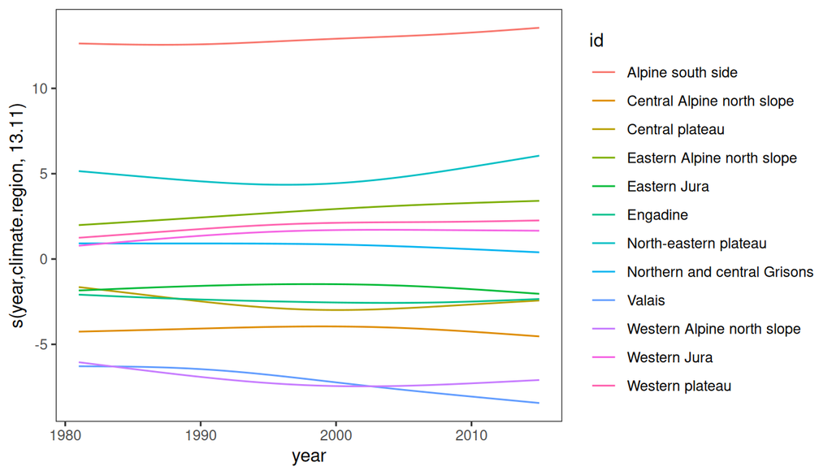

```r
plot(sm(fit2, 3)) + l_fitLine(alpha = 1)
```

The effect of year-by-region is using relatively few degrees of freedom (`edf`), there might have been a slight decrease in rainfall in Valais, for instance.

3. Fit a 3D spatio-temporal tensor product effect:

```r
fit <- qgamV(exra ~ s(nao) + s(elevation) + climate.region +
                    te(E, N, year, d = c(2, 1), k = c(20, 5)),
                    data = swer, qu = 0.5)
```

```
## Estimating learning rate. Each dot corresponds to a loss evaluation.
## qu = 0.5..........done
```

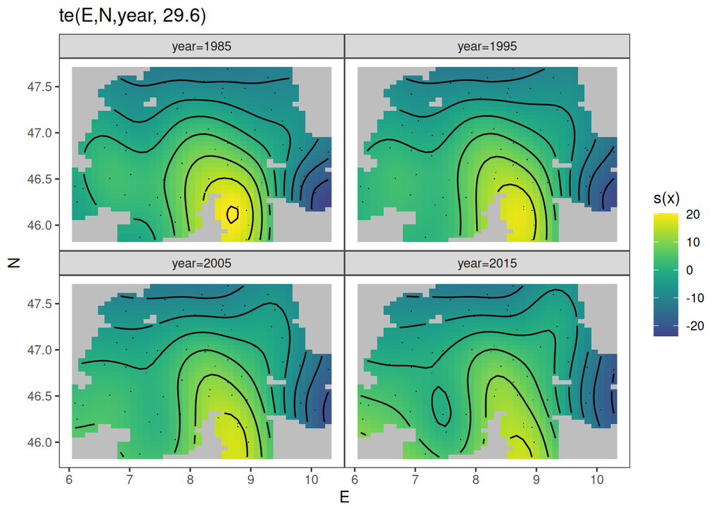

```r
plotSlice(x = sm(fit, 3),
          fix = list("year" = c(1985, 1995, 2005, 2015))) + l_fitRaster() +
          l_fitContour() + l_points()
```

There doesn’t seem to be much change in the precipication pattern, maybe there is a decrease of rainfall levels in the South East (in the Canton of Ticino).

4. We plot one slice through time using `rgl`:

```r
plotRGL(x = sm(fit, 3), fix = c("year" = 1985), residuals = TRUE)
rglwidget()
```

[interactive chart not shown]

5. Remove the tensor effect w.r.t. time and fit the model to several quantiles:

```r
fitM <- mqgamV(exra ~ s(nao) + s(elevation) + climate.region + s(E, N) + s(year, k = 5),
               data = swer, qu = seq(0.1, 0.9, length.out = 9) )
```

```
## Estimating learning rate. Each dot corresponds to a loss evaluation.
## qu = 0.5..............done
## qu = 0.4...........done
## qu = 0.6...............done
## qu = 0.3.........done
## qu = 0.7............done
## qu = 0.2...........done
## qu = 0.8..........done
## qu = 0.1......................done
## qu = 0.9...........done
```

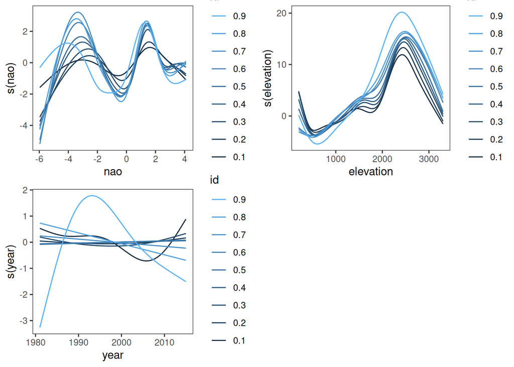

```r
# Plot univariate smooths
print(plot(fitM, select = c(1, 2, 4)), pages = 1)
```

```r
summary(fitM[[9]])
```

```
##
## Family: elf
## Link function: identity
##
## Formula:
## exra ~ s(nao) + s(elevation) + climate.region + s(E, N) + s(year,
##     k = 5)
##
## Parametric coefficients:
##                                            Estimate Std. Error z value Pr(>|z|)
## (Intercept)                                  98.597      7.676  12.844  < 2e-16
## climate.regionCentral Alpine north slope    -24.764      9.538  -2.596  0.00942
## climate.regionCentral plateau               -30.277     11.388  -2.659  0.00785
## climate.regionEastern Alpine north slope    -10.062     12.178  -0.826  0.40867
## climate.regionEastern Jura                  -25.756     12.434  -2.071  0.03833
## climate.regionEngadine                      -20.299      7.153  -2.838  0.00454
## climate.regionNorth-eastern plateau         -23.712     12.634  -1.877  0.06054
## climate.regionNorthern and central Grisons  -11.603      7.828  -1.482  0.13829
## climate.regionValais                        -33.695     10.353  -3.255  0.00114
## climate.regionWestern Alpine north slope    -33.909      9.727  -3.486  0.00049
## climate.regionWestern Jura                  -21.638     14.011  -1.544  0.12249
## climate.regionWestern plateau               -22.494     13.000  -1.730  0.08359
##
## (Intercept)                                ***
## climate.regionCentral Alpine north slope   **
## climate.regionCentral plateau              **
## climate.regionEastern Alpine north slope
## climate.regionEastern Jura                 *
## climate.regionEngadine                     **
## climate.regionNorth-eastern plateau        .
## climate.regionNorthern and central Grisons
## climate.regionValais                       **
## climate.regionWestern Alpine north slope   ***
## climate.regionWestern Jura
## climate.regionWestern plateau              .
## ---
## Signif. codes:  0 '***' 0.001 '**' 0.01 '*' 0.05 '.' 0.1 ' ' 1
##
## Approximate significance of smooth terms:
##                 edf Ref.df  Chi.sq p-value
## s(nao)        4.541  5.473   9.414   0.200
## s(elevation)  4.362  5.180  44.861  <2e-16 ***
## s(E,N)       23.820 26.979 226.357  <2e-16 ***
## s(year)       2.440  2.931   4.150   0.173
## ---
## Signif. codes:  0 '***' 0.001 '**' 0.01 '*' 0.05 '.' 0.1 ' ' 1
##
## R-sq.(adj) =  0.403   Deviance explained = 70.9%
## -REML =  10697  Scale est. = 1         n = 2196
```

The effect of `year` seems to be highly non-linear for quantile 0.9, but `summary` shows that this effect is not significant.

We can also plot the spatial effect:

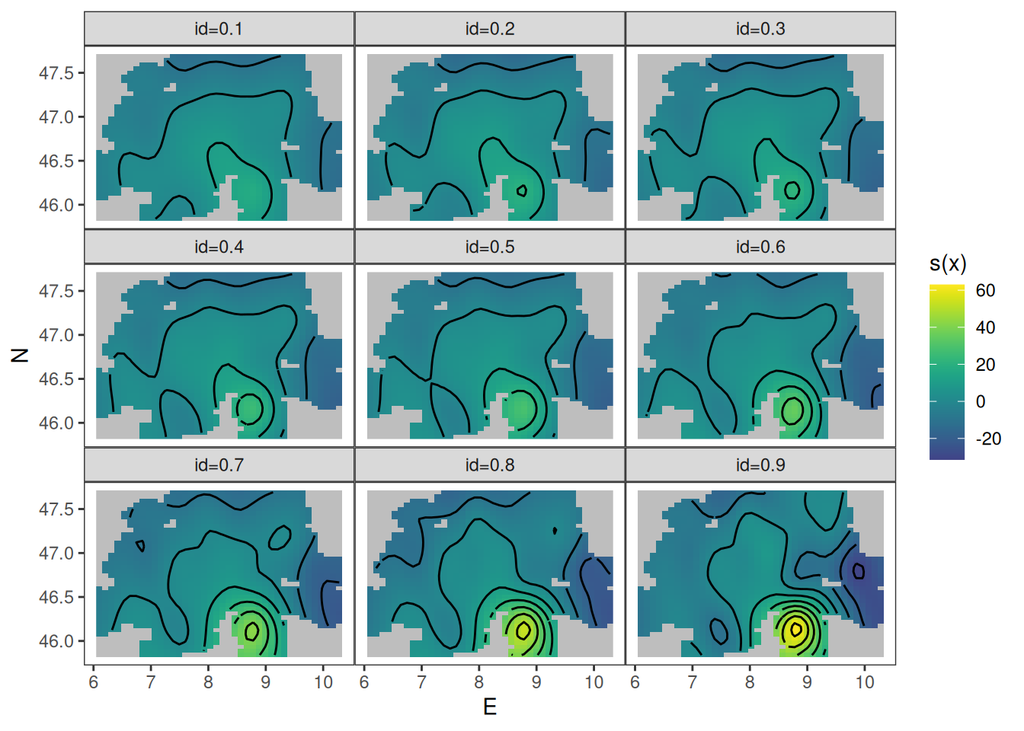

```r
print(plot(fitM, select = 3), pages = 1)
```

As expected, the spatial effect is much stronger for high quantiles (extreme rainfall) than for the low ones. For quantile 0.9 the spatial effect varies between +50mm in the Canton of Ticino and -30mm in the Canton of Grisons.

Finally we can see how the climate region effect changes depending on the quantile of interest:

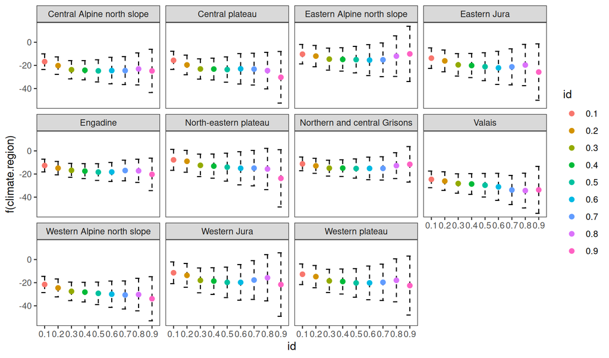

```r
print(plot(fitM, select = 5), pages = 1)
```